# Risk Factor Analysis

## Outcome Variable

**Outcome Variable:** pers_wasted624

## Predictor Variables

**Intervention Variable:** pers_wasted06

**Adjustment Set:**

- sex
- arm
- brthmon
- vagbrth
- single
- W_mage
- W_mhtcm
- W_mwtkg
- W_mbmi
- W_meducyrs
- W_feducyrs
- W_parity
- delta_brthmon
- delta_vagbrth
- delta_single
- delta_W_mage
- delta_W_mhtcm
- delta_W_mwtkg
- delta_W_mbmi
- delta_W_meducyrs
- delta_W_feducyrs
- delta_W_parity

## Stratifying Variables

The analysis was stratified on these variable(s):

- studyid
- country

## Data Summary

| studyid | country | pers_wasted06 | pers_wasted624 | n_cell | n | outcome_variable |
| --- | --- | --- | --- | --- | --- | --- |
| ki0047075b-MAL-ED | BANGLADESH | 0 | 0 | 219 | 240 | pers_wasted624 |
| ki0047075b-MAL-ED | BANGLADESH | 0 | 1 | 13 | 240 | pers_wasted624 |
| ki0047075b-MAL-ED | BANGLADESH | 1 | 0 | 4 | 240 | pers_wasted624 |
| ki0047075b-MAL-ED | BANGLADESH | 1 | 1 | 4 | 240 | pers_wasted624 |
| ki0047075b-MAL-ED | BRAZIL | 0 | 0 | 205 | 207 | pers_wasted624 |
| ki0047075b-MAL-ED | BRAZIL | 0 | 1 | 1 | 207 | pers_wasted624 |
| ki0047075b-MAL-ED | BRAZIL | 1 | 0 | 0 | 207 | pers_wasted624 |
| ki0047075b-MAL-ED | BRAZIL | 1 | 1 | 1 | 207 | pers_wasted624 |
| ki0047075b-MAL-ED | INDIA | 0 | 0 | 202 | 235 | pers_wasted624 |
| ki0047075b-MAL-ED | INDIA | 0 | 1 | 18 | 235 | pers_wasted624 |
| ki0047075b-MAL-ED | INDIA | 1 | 0 | 5 | 235 | pers_wasted624 |
| ki0047075b-MAL-ED | INDIA | 1 | 1 | 10 | 235 | pers_wasted624 |
| ki0047075b-MAL-ED | NEPAL | 0 | 0 | 231 | 235 | pers_wasted624 |
| ki0047075b-MAL-ED | NEPAL | 0 | 1 | 1 | 235 | pers_wasted624 |
| ki0047075b-MAL-ED | NEPAL | 1 | 0 | 2 | 235 | pers_wasted624 |
| ki0047075b-MAL-ED | NEPAL | 1 | 1 | 1 | 235 | pers_wasted624 |
| ki0047075b-MAL-ED | PERU | 0 | 0 | 267 | 270 | pers_wasted624 |
| ki0047075b-MAL-ED | PERU | 0 | 1 | 3 | 270 | pers_wasted624 |
| ki0047075b-MAL-ED | PERU | 1 | 0 | 0 | 270 | pers_wasted624 |
| ki0047075b-MAL-ED | PERU | 1 | 1 | 0 | 270 | pers_wasted624 |
| ki0047075b-MAL-ED | SOUTH AFRICA | 0 | 0 | 256 | 259 | pers_wasted624 |
| ki0047075b-MAL-ED | SOUTH AFRICA | 0 | 1 | 0 | 259 | pers_wasted624 |
| ki0047075b-MAL-ED | SOUTH AFRICA | 1 | 0 | 1 | 259 | pers_wasted624 |
| ki0047075b-MAL-ED | SOUTH AFRICA | 1 | 1 | 2 | 259 | pers_wasted624 |
| ki0047075b-MAL-ED | TANZANIA, UNITED REPUBLIC OF | 0 | 0 | 245 | 245 | pers_wasted624 |
| ki0047075b-MAL-ED | TANZANIA, UNITED REPUBLIC OF | 0 | 1 | 0 | 245 | pers_wasted624 |
| ki0047075b-MAL-ED | TANZANIA, UNITED REPUBLIC OF | 1 | 0 | 0 | 245 | pers_wasted624 |
| ki0047075b-MAL-ED | TANZANIA, UNITED REPUBLIC OF | 1 | 1 | 0 | 245 | pers_wasted624 |
| ki1000108-CMC-V-BCS-2002 | INDIA | 0 | 0 | 307 | 370 | pers_wasted624 |
| ki1000108-CMC-V-BCS-2002 | INDIA | 0 | 1 | 11 | 370 | pers_wasted624 |

[output cut: 90 more lines]

The following strata were considered:

- studyid: ki0047075b-MAL-ED, country: BANGLADESH
- studyid: ki0047075b-MAL-ED, country: BRAZIL
- studyid: ki0047075b-MAL-ED, country: INDIA
- studyid: ki0047075b-MAL-ED, country: NEPAL
- studyid: ki0047075b-MAL-ED, country: PERU
- studyid: ki0047075b-MAL-ED, country: SOUTH AFRICA
- studyid: ki0047075b-MAL-ED, country: TANZANIA, UNITED REPUBLIC OF
- studyid: ki1000108-CMC-V-BCS-2002, country: INDIA
- studyid: ki1000108-IRC, country: INDIA
- studyid: ki1000109-EE, country: PAKISTAN
- studyid: ki1000109-ResPak, country: PAKISTAN
- studyid: ki1000304b-SAS-CompFeed, country: INDIA
- studyid: ki1000304b-SAS-FoodSuppl, country: INDIA
- studyid: ki1017093-NIH-Birth, country: BANGLADESH
- studyid: ki1017093b-PROVIDE, country: BANGLADESH
- studyid: ki1017093c-NIH-Crypto, country: BANGLADESH
- studyid: ki1066203-TanzaniaChild2, country: TANZANIA, UNITED REPUBLIC OF
- studyid: ki1101329-Keneba, country: GAMBIA
- studyid: ki1112895-Guatemala BSC, country: GUATEMALA
- studyid: ki1113344-GMS-Nepal, country: NEPAL
- studyid: ki1114097-CMIN, country: BANGLADESH
- studyid: ki1114097-CONTENT, country: PERU
- studyid: ki1119695-PROBIT, country: BELARUS
- studyid: ki1126311-ZVITAMBO, country: ZIMBABWE
- studyid: ki1135781-COHORTS, country: GUATEMALA
- studyid: ki1135781-COHORTS, country: INDIA
- studyid: ki1135781-COHORTS, country: PHILIPPINES
- studyid: ki1148112-LCNI-5, country: MALAWI
- studyid: kiGH5241-JiVitA-3, country: BANGLADESH
- studyid: kiGH5241-JiVitA-4, country: BANGLADESH

### Dropped Strata

Some strata were dropped due to rare outcomes:

- studyid: ki0047075b-MAL-ED, country: BANGLADESH
- studyid: ki0047075b-MAL-ED, country: BRAZIL
- studyid: ki0047075b-MAL-ED, country: NEPAL
- studyid: ki0047075b-MAL-ED, country: PERU
- studyid: ki0047075b-MAL-ED, country: SOUTH AFRICA
- studyid: ki0047075b-MAL-ED, country: TANZANIA, UNITED REPUBLIC OF
- studyid: ki1112895-Guatemala BSC, country: GUATEMALA
- studyid: ki1114097-CMIN, country: BANGLADESH
- studyid: ki1114097-CONTENT, country: PERU

## Methods Detail

We’re interested in the causal parameters $E[Y_a]$ for all values of $a \in \mathcal{A}$. These parameters represent the mean outcome if, possibly contrary to fact, we intervened to set all units to have $A=a$. Under the randomization and positivity assumptions, these are identified by the statistical parameters $\psi_a=E_W[E_{Y|A,W}(Y|A=a,W)]$. In addition, we’re interested in the mean of $Y$, $E[Y]$ under no intervention (the observed mean). We will estimate these parameters by using SuperLearner to fit the relevant likelihood factors – $E_{Y|A,W}(Y|A=a,W)$ and $p(A=a|W)$, and then updating our likelihood fit using a joint TMLE.

For unadjusted analyses ($W=\{\}$), initial likelihoods were estimated using Lrnr_glm to estimate the simple $E(Y|A)$ and Lrnr_mean to estimate $p(A)$. For adjusted analyses, a small library containing Lrnr_glmnet, Lrnr_xgboost, and Lrnr_mean was used.

Having estimated these parameters, we will then use the delta method to estimate relative risks and attributable risks relative to a prespecified baseline level of $A$.

# Results Detail

## Results Plots

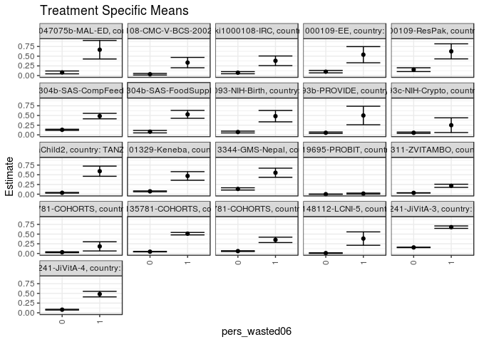

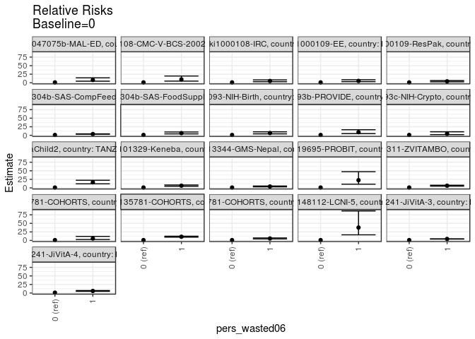

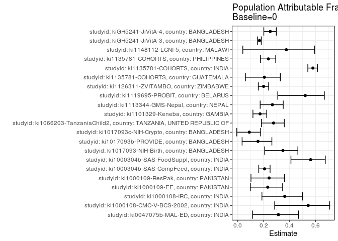

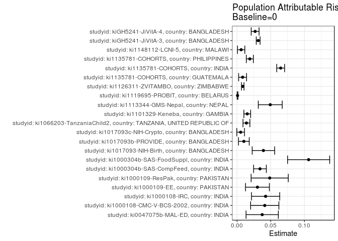

## Results Table

### Parameter: TSM

| studyid | country | intervention_level | baseline_level | estimate | ci_lower | ci_upper |
| --- | --- | --- | --- | --- | --- | --- |
| ki0047075b-MAL-ED | INDIA | 0 | NA | 0.0818182 | 0.0455227 | 0.1181136 |
| ki0047075b-MAL-ED | INDIA | 1 | NA | 0.6666667 | 0.4275982 | 0.9057351 |
| ki1000108-CMC-V-BCS-2002 | INDIA | 0 | NA | 0.0345465 | 0.0143877 | 0.0547052 |
| ki1000108-CMC-V-BCS-2002 | INDIA | 1 | NA | 0.3351494 | 0.2017984 | 0.4685005 |
| ki1000108-IRC | INDIA | 0 | NA | 0.0746864 | 0.0470794 | 0.1022934 |
| ki1000108-IRC | INDIA | 1 | NA | 0.3813117 | 0.2571611 | 0.5054623 |
| ki1000109-EE | PAKISTAN | 0 | NA | 0.1007427 | 0.0690710 | 0.1324145 |
| ki1000109-EE | PAKISTAN | 1 | NA | 0.5385543 | 0.3298215 | 0.7472871 |
| ki1000109-ResPak | PAKISTAN | 0 | NA | 0.1523810 | 0.1036692 | 0.2010927 |
| ki1000109-ResPak | PAKISTAN | 1 | NA | 0.6250000 | 0.4308989 | 0.8191011 |
| ki1000304b-SAS-CompFeed | INDIA | 0 | NA | 0.1307143 | 0.1160927 | 0.1453359 |
| ki1000304b-SAS-CompFeed | INDIA | 1 | NA | 0.4844115 | 0.4139448 | 0.5548781 |
| ki1000304b-SAS-FoodSuppl | INDIA | 0 | NA | 0.0828296 | 0.0517850 | 0.1138742 |
| ki1000304b-SAS-FoodSuppl | INDIA | 1 | NA | 0.5287956 | 0.4271295 | 0.6304617 |
| ki1017093-NIH-Birth | BANGLADESH | 0 | NA | 0.0733951 | 0.0503290 | 0.0964612 |
| ki1017093-NIH-Birth | BANGLADESH | 1 | NA | 0.4825920 | 0.3363063 | 0.6288777 |
| ki1017093b-PROVIDE | BANGLADESH | 0 | NA | 0.0549085 | 0.0366394 | 0.0731775 |
| ki1017093b-PROVIDE | BANGLADESH | 1 | NA | 0.5000000 | 0.2613176 | 0.7386824 |
| ki1017093c-NIH-Crypto | BANGLADESH | 0 | NA | 0.0549296 | 0.0381589 | 0.0717003 |
| ki1017093c-NIH-Crypto | BANGLADESH | 1 | NA | 0.2500000 | 0.0600972 | 0.4399028 |
| ki1066203-TanzaniaChild2 | TANZANIA, UNITED REPUBLIC OF | 0 | NA | 0.0366083 | 0.0282868 | 0.0449298 |
| ki1066203-TanzaniaChild2 | TANZANIA, UNITED REPUBLIC OF | 1 | NA | 0.5928056 | 0.4616942 | 0.7239171 |
| ki1101329-Keneba | GAMBIA | 0 | NA | 0.0731724 | 0.0623234 | 0.0840214 |
| ki1101329-Keneba | GAMBIA | 1 | NA | 0.4703451 | 0.3591136 | 0.5815767 |
| ki1113344-GMS-Nepal | NEPAL | 0 | NA | 0.1354582 | 0.1061555 | 0.1647609 |
| ki1113344-GMS-Nepal | NEPAL | 1 | NA | 0.5528126 | 0.4348531 | 0.6707722 |
| ki1119695-PROBIT | BELARUS | 0 | NA | 0.0006934 | 0.0001315 | 0.0012552 |
| ki1119695-PROBIT | BELARUS | 1 | NA | 0.0156167 | 0.0029547 | 0.0282788 |
| ki1126311-ZVITAMBO | ZIMBABWE | 0 | NA | 0.0341149 | 0.0305903 | 0.0376396 |
| ki1126311-ZVITAMBO | ZIMBABWE | 1 | NA | 0.2161647 | 0.1758092 | 0.2565201 |
| ki1135781-COHORTS | GUATEMALA | 0 | NA | 0.0320545 | 0.0209079 | 0.0432012 |
| ki1135781-COHORTS | GUATEMALA | 1 | NA | 0.1834347 | 0.0649378 | 0.3019315 |
| ki1135781-COHORTS | INDIA | 0 | NA | 0.0469890 | 0.0416288 | 0.0523492 |
| ki1135781-COHORTS | INDIA | 1 | NA | 0.5108972 | 0.4788966 | 0.5428979 |
| ki1135781-COHORTS | PHILIPPINES | 0 | NA | 0.0615085 | 0.0523406 | 0.0706763 |
| ki1135781-COHORTS | PHILIPPINES | 1 | NA | 0.3510034 | 0.2814870 | 0.4205197 |
| ki1148112-LCNI-5 | MALAWI | 0 | NA | 0.0102041 | 0.0031022 | 0.0173060 |
| ki1148112-LCNI-5 | MALAWI | 1 | NA | 0.3846154 | 0.2119598 | 0.5572710 |
| kiGH5241-JiVitA-3 | BANGLADESH | 0 | NA | 0.1566413 | 0.1504722 | 0.1628104 |
| kiGH5241-JiVitA-3 | BANGLADESH | 1 | NA | 0.6795114 | 0.6482484 | 0.7107744 |
| kiGH5241-JiVitA-4 | BANGLADESH | 0 | NA | 0.0804159 | 0.0710777 | 0.0897542 |
| kiGH5241-JiVitA-4 | BANGLADESH | 1 | NA | 0.4817463 | 0.4100945 | 0.5533981 |

### Parameter: E(Y)

| studyid | country | intervention_level | baseline_level | estimate | ci_lower | ci_upper |
| --- | --- | --- | --- | --- | --- | --- |
| ki0047075b-MAL-ED | INDIA | NA | NA | 0.1191489 | 0.0776405 | 0.1606574 |
| ki1000108-CMC-V-BCS-2002 | INDIA | NA | NA | 0.0756757 | 0.0486905 | 0.1026609 |
| ki1000108-IRC | INDIA | NA | NA | 0.1170732 | 0.0859146 | 0.1482317 |
| ki1000109-EE | PAKISTAN | NA | NA | 0.1310160 | 0.0967738 | 0.1652583 |
| ki1000109-ResPak | PAKISTAN | NA | NA | 0.2008547 | 0.1494120 | 0.2522974 |
| ki1000304b-SAS-CompFeed | INDIA | NA | NA | 0.1647399 | 0.1451050 | 0.1843747 |
| ki1000304b-SAS-FoodSuppl | INDIA | NA | NA | 0.1890547 | 0.1507312 | 0.2273783 |
| ki1017093-NIH-Birth | BANGLADESH | NA | NA | 0.1125461 | 0.0859151 | 0.1391771 |
| ki1017093b-PROVIDE | BANGLADESH | NA | NA | 0.0650407 | 0.0455353 | 0.0845460 |
| ki1017093c-NIH-Crypto | BANGLADESH | NA | NA | 0.0602740 | 0.0429977 | 0.0775502 |
| ki1066203-TanzaniaChild2 | TANZANIA, UNITED REPUBLIC OF | NA | NA | 0.0505451 | 0.0409848 | 0.0601054 |
| ki1101329-Keneba | GAMBIA | NA | NA | 0.0883377 | 0.0767324 | 0.0999430 |
| ki1113344-GMS-Nepal | NEPAL | NA | NA | 0.1847458 | 0.1534039 | 0.2160876 |
| ki1119695-PROBIT | BELARUS | NA | NA | 0.0014461 | 0.0004206 | 0.0024716 |
| ki1126311-ZVITAMBO | ZIMBABWE | NA | NA | 0.0425869 | 0.0387663 | 0.0464075 |
| ki1135781-COHORTS | GUATEMALA | NA | NA | 0.0403147 | 0.0282199 | 0.0524094 |
| ki1135781-COHORTS | INDIA | NA | NA | 0.1117237 | 0.1042858 | 0.1191617 |
| ki1135781-COHORTS | PHILIPPINES | NA | NA | 0.0804843 | 0.0704205 | 0.0905481 |
| ki1148112-LCNI-5 | MALAWI | NA | NA | 0.0163112 | 0.0075116 | 0.0251108 |
| kiGH5241-JiVitA-3 | BANGLADESH | NA | NA | 0.1880070 | 0.1814627 | 0.1945512 |
| kiGH5241-JiVitA-4 | BANGLADESH | NA | NA | 0.1072724 | 0.0967392 | 0.1178055 |

### Parameter: RR

| studyid | country | intervention_level | baseline_level | estimate | ci_lower | ci_upper |
| --- | --- | --- | --- | --- | --- | --- |
| ki0047075b-MAL-ED | INDIA | 0 | 0 | 1.000000 | 1.000000 | 1.000000 |
| ki0047075b-MAL-ED | INDIA | 1 | 0 | 8.148148 | 4.606020 | 14.414249 |
| ki1000108-CMC-V-BCS-2002 | INDIA | 0 | 0 | 1.000000 | 1.000000 | 1.000000 |
| ki1000108-CMC-V-BCS-2002 | INDIA | 1 | 0 | 9.701408 | 4.779956 | 19.689994 |
| ki1000108-IRC | INDIA | 0 | 0 | 1.000000 | 1.000000 | 1.000000 |
| ki1000108-IRC | INDIA | 1 | 0 | 5.105504 | 3.113501 | 8.371981 |
| ki1000109-EE | PAKISTAN | 0 | 0 | 1.000000 | 1.000000 | 1.000000 |
| ki1000109-EE | PAKISTAN | 1 | 0 | 5.345838 | 3.239367 | 8.822090 |
| ki1000109-ResPak | PAKISTAN | 0 | 0 | 1.000000 | 1.000000 | 1.000000 |
| ki1000109-ResPak | PAKISTAN | 1 | 0 | 4.101562 | 2.626572 | 6.404857 |
| ki1000304b-SAS-CompFeed | INDIA | 0 | 0 | 1.000000 | 1.000000 | 1.000000 |
| ki1000304b-SAS-CompFeed | INDIA | 1 | 0 | 3.705879 | 3.203988 | 4.286391 |
| ki1000304b-SAS-FoodSuppl | INDIA | 0 | 0 | 1.000000 | 1.000000 | 1.000000 |
| ki1000304b-SAS-FoodSuppl | INDIA | 1 | 0 | 6.384135 | 4.189709 | 9.727928 |
| ki1017093-NIH-Birth | BANGLADESH | 0 | 0 | 1.000000 | 1.000000 | 1.000000 |
| ki1017093-NIH-Birth | BANGLADESH | 1 | 0 | 6.575265 | 4.244791 | 10.185215 |
| ki1017093b-PROVIDE | BANGLADESH | 0 | 0 | 1.000000 | 1.000000 | 1.000000 |
| ki1017093b-PROVIDE | BANGLADESH | 1 | 0 | 9.106061 | 5.088919 | 16.294295 |
| ki1017093c-NIH-Crypto | BANGLADESH | 0 | 0 | 1.000000 | 1.000000 | 1.000000 |
| ki1017093c-NIH-Crypto | BANGLADESH | 1 | 0 | 4.551282 | 2.007191 | 10.319981 |
| ki1066203-TanzaniaChild2 | TANZANIA, UNITED REPUBLIC OF | 0 | 0 | 1.000000 | 1.000000 | 1.000000 |
| ki1066203-TanzaniaChild2 | TANZANIA, UNITED REPUBLIC OF | 1 | 0 | 16.193215 | 11.787812 | 22.245030 |
| ki1101329-Keneba | GAMBIA | 0 | 0 | 1.000000 | 1.000000 | 1.000000 |
| ki1101329-Keneba | GAMBIA | 1 | 0 | 6.427905 | 4.864452 | 8.493858 |
| ki1113344-GMS-Nepal | NEPAL | 0 | 0 | 1.000000 | 1.000000 | 1.000000 |
| ki1113344-GMS-Nepal | NEPAL | 1 | 0 | 4.081057 | 3.012784 | 5.528119 |
| ki1119695-PROBIT | BELARUS | 0 | 0 | 1.000000 | 1.000000 | 1.000000 |
| ki1119695-PROBIT | BELARUS | 1 | 0 | 22.522101 | 10.723164 | 47.303672 |
| ki1126311-ZVITAMBO | ZIMBABWE | 0 | 0 | 1.000000 | 1.000000 | 1.000000 |
| ki1126311-ZVITAMBO | ZIMBABWE | 1 | 0 | 6.336369 | 5.120322 | 7.841220 |
| ki1135781-COHORTS | GUATEMALA | 0 | 0 | 1.000000 | 1.000000 | 1.000000 |
| ki1135781-COHORTS | GUATEMALA | 1 | 0 | 5.722586 | 2.754338 | 11.889607 |
| ki1135781-COHORTS | INDIA | 0 | 0 | 1.000000 | 1.000000 | 1.000000 |
| ki1135781-COHORTS | INDIA | 1 | 0 | 10.872691 | 9.549895 | 12.378713 |
| ki1135781-COHORTS | PHILIPPINES | 0 | 0 | 1.000000 | 1.000000 | 1.000000 |
| ki1135781-COHORTS | PHILIPPINES | 1 | 0 | 5.706588 | 4.457127 | 7.306309 |
| ki1148112-LCNI-5 | MALAWI | 0 | 0 | 1.000000 | 1.000000 | 1.000000 |
| ki1148112-LCNI-5 | MALAWI | 1 | 0 | 37.692308 | 16.465322 | 86.284983 |
| kiGH5241-JiVitA-3 | BANGLADESH | 0 | 0 | 1.000000 | 1.000000 | 1.000000 |
| kiGH5241-JiVitA-3 | BANGLADESH | 1 | 0 | 4.338009 | 4.093453 | 4.597176 |
| kiGH5241-JiVitA-4 | BANGLADESH | 0 | 0 | 1.000000 | 1.000000 | 1.000000 |
| kiGH5241-JiVitA-4 | BANGLADESH | 1 | 0 | 5.990681 | 4.966558 | 7.225982 |

### Parameter: PAR

| studyid | country | intervention_level | baseline_level | estimate | ci_lower | ci_upper |
| --- | --- | --- | --- | --- | --- | --- |
| ki0047075b-MAL-ED | INDIA | 0 | NA | 0.0373308 | 0.0133773 | 0.0612842 |
| ki1000108-CMC-V-BCS-2002 | INDIA | 0 | NA | 0.0411292 | 0.0201588 | 0.0620996 |
| ki1000108-IRC | INDIA | 0 | NA | 0.0423868 | 0.0214521 | 0.0633214 |
| ki1000109-EE | PAKISTAN | 0 | NA | 0.0302733 | 0.0125641 | 0.0479826 |
| ki1000109-ResPak | PAKISTAN | 0 | NA | 0.0484737 | 0.0209011 | 0.0760464 |
| ki1000304b-SAS-CompFeed | INDIA | 0 | NA | 0.0340256 | 0.0245818 | 0.0434693 |
| ki1000304b-SAS-FoodSuppl | INDIA | 0 | NA | 0.1062251 | 0.0749866 | 0.1374636 |
| ki1017093-NIH-Birth | BANGLADESH | 0 | NA | 0.0391511 | 0.0225002 | 0.0558020 |
| ki1017093b-PROVIDE | BANGLADESH | 0 | NA | 0.0101322 | 0.0021706 | 0.0180938 |
| ki1017093c-NIH-Crypto | BANGLADESH | 0 | NA | 0.0053444 | -0.0003673 | 0.0110561 |
| ki1066203-TanzaniaChild2 | TANZANIA, UNITED REPUBLIC OF | 0 | NA | 0.0139368 | 0.0088300 | 0.0190437 |
| ki1101329-Keneba | GAMBIA | 0 | NA | 0.0151653 | 0.0101236 | 0.0202070 |
| ki1113344-GMS-Nepal | NEPAL | 0 | NA | 0.0492876 | 0.0315201 | 0.0670550 |
| ki1119695-PROBIT | BELARUS | 0 | NA | 0.0007527 | 0.0001702 | 0.0013353 |
| ki1126311-ZVITAMBO | ZIMBABWE | 0 | NA | 0.0084720 | 0.0066229 | 0.0103211 |
| ki1135781-COHORTS | GUATEMALA | 0 | NA | 0.0082601 | 0.0023893 | 0.0141310 |
| ki1135781-COHORTS | INDIA | 0 | NA | 0.0647347 | 0.0588952 | 0.0705742 |
| ki1135781-COHORTS | PHILIPPINES | 0 | NA | 0.0189759 | 0.0137559 | 0.0241958 |
| ki1148112-LCNI-5 | MALAWI | 0 | NA | 0.0061071 | 0.0006741 | 0.0115401 |
| kiGH5241-JiVitA-3 | BANGLADESH | 0 | NA | 0.0313657 | 0.0285164 | 0.0342149 |
| kiGH5241-JiVitA-4 | BANGLADESH | 0 | NA | 0.0268564 | 0.0210174 | 0.0326955 |

### Parameter: PAF

| studyid | country | intervention_level | baseline_level | estimate | ci_lower | ci_upper |
| --- | --- | --- | --- | --- | --- | --- |
| ki0047075b-MAL-ED | INDIA | 0 | NA | 0.3133117 | 0.1136573 | 0.4679927 |
| ki1000108-CMC-V-BCS-2002 | INDIA | 0 | NA | 0.5434930 | 0.2845438 | 0.7087192 |
| ki1000108-IRC | INDIA | 0 | NA | 0.3620536 | 0.1860034 | 0.5000279 |
| ki1000109-EE | PAKISTAN | 0 | NA | 0.2310658 | 0.0963221 | 0.3457183 |
| ki1000109-ResPak | PAKISTAN | 0 | NA | 0.2413374 | 0.1014563 | 0.3594424 |
| ki1000304b-SAS-CompFeed | INDIA | 0 | NA | 0.2065412 | 0.1616542 | 0.2490249 |
| ki1000304b-SAS-FoodSuppl | INDIA | 0 | NA | 0.5618748 | 0.4100278 | 0.6746395 |
| ki1017093-NIH-Birth | BANGLADESH | 0 | NA | 0.3478668 | 0.2073937 | 0.4634440 |
| ki1017093b-PROVIDE | BANGLADESH | 0 | NA | 0.1557820 | 0.0331417 | 0.2628662 |
| ki1017093c-NIH-Crypto | BANGLADESH | 0 | NA | 0.0886684 | -0.0078075 | 0.1759087 |
| ki1066203-TanzaniaChild2 | TANZANIA, UNITED REPUBLIC OF | 0 | NA | 0.2757304 | 0.1822986 | 0.3584866 |
| ki1101329-Keneba | GAMBIA | 0 | NA | 0.1716742 | 0.1166985 | 0.2232283 |
| ki1113344-GMS-Nepal | NEPAL | 0 | NA | 0.2667859 | 0.1725246 | 0.3503094 |
| ki1119695-PROBIT | BELARUS | 0 | NA | 0.5205169 | 0.3083126 | 0.6676185 |
| ki1126311-ZVITAMBO | ZIMBABWE | 0 | NA | 0.1989341 | 0.1580474 | 0.2378353 |
| ki1135781-COHORTS | GUATEMALA | 0 | NA | 0.2048919 | 0.0593522 | 0.3279132 |
| ki1135781-COHORTS | INDIA | 0 | NA | 0.5794177 | 0.5402482 | 0.6152500 |
| ki1135781-COHORTS | PHILIPPINES | 0 | NA | 0.2357711 | 0.1746573 | 0.2923597 |
| ki1148112-LCNI-5 | MALAWI | 0 | NA | 0.3744113 | 0.0387300 | 0.5928707 |
| kiGH5241-JiVitA-3 | BANGLADESH | 0 | NA | 0.1668324 | 0.1524775 | 0.1809442 |
| kiGH5241-JiVitA-4 | BANGLADESH | 0 | NA | 0.2503574 | 0.2007340 | 0.2968999 |